# Evolution de l’opinion sur l’homosexualité entre 2002 et 2019

Le cas de la France

Eva Racine

17/12/2024

# Objectif

## Votre mission

Les Nations-Unies ont lancé une vaste étude internationale sur l’évolution de l’opinion mondiale sur l’homosexualité. Pour cela, elles sont constitué un échantillon de 24 pays pour lesquels on dispose d’enquêtes réalisées par le Pew Research Center en 2002 et 2019 dans le cadre de la Global Attitude Survey.

Un expert a été désigné pour chaque pays afin de répondre à une série de questions. Il est demandé aux experts d’adopter une attitude de stricte neutralité scientifique et de tester une série d’hypothèses sans faire intervenir leur propre opinion.

Vous avez été désigné pour étudier le cas de la France. Vous indiquerez son code ci-dessous :

```r
mysta <- "FRA"
```

Mais on attend également de vous des comparaisons avec des **pays proches sur le plan économique et géographique**. Vous devrez donc discuter vos résultats avec un ou deux autres experts responsables de pays qui ressemble au vôtre.

## Base de données

Voici le fichier général des 24 pays aux deux dates

```r
base<-readRDS(file = "data/pew_hom_rel.RDS")
head(base)
```

```
##    wav sta wgt   sex age           rel      hom
## 1 2002 ARG   1 Femme  37     Important Accepter
## 2 2002 ARG   1 Homme  64 Pas important Accepter
## 3 2002 ARG   1 Femme  25     Important  Refuser
## 4 2002 ARG   1 Homme  40 Pas important Accepter
## 5 2002 ARG   1 Femme  48 Pas important Accepter
## 6 2002 ARG   1 Homme  86 Pas important Accepter
```

[output not shown]

## Nouvelles variables

On décide d’ajouter quelques nouvelles variables. Le travail a été fait pour toutes … sauf pour le découpage des âges et des générations en classes. C’est à vous de choisir … et de justifier (cf. Question D)

```r
# identification de mon pays
base$mysta<-base$sta==mysta
base$mysta<-as.factor(base$mysta)
levels(base$mysta)<-c("Autre pays","Mon pays")

# identificationde la génération (année de naissance)
base$gen <- 2002-base$age
base$gen[base$wav==2019]<-2019-base$age[base$wav==2019]

# recodage de la variable Y à expliquer en deux variables
base$hom_nr<-base$hom
levels(base$hom_nr) <- c("Réponse","Réponse","Non Réponse","Non Réponse")
base$hom_opi <-base$hom
levels(base$hom_opi) <- c("Accepter","Refuser",NA,NA)

# recodage de la variable X explicative en deux variables
base$rel_nr<-base$rel
levels(base$rel_nr) <- c("Réponse","Réponse","Non Réponse","Non Réponse")
base$rel_opi <-base$rel
levels(base$rel)
```

```
## [1] "Pas important" "Important"     "NSP"           "RR"
```

```r
levels(base$rel_opi) <- c("Pas Important","Important",NA,NA)


# Découpage de la variable âge en classes
base$age3<-cut(base$age, breaks=c(0,29,55,100))
levels(base$age3)<-c("Jeunes","Adultes","Agé")
table(base$age3)
```

```
##
##  Jeunes Adultes     Agé
##   11770   22256   13390
```

```r
# Découpage de la variable génération en classes
base$gen3<-cut(base$gen, breaks=c(1900,1950,1990,2002))
levels(base$gen3)<-c("1900-1950","1950-1990","1990-2002")
table(base$gen3)
```

```
##
## 1900-1950 1950-1990 1990-2002
##      9173     32503      5740
```

```r
# Séparation de la base générale en deux dates
base1 <-base[base$wav == 2002,]
base2 <-base[base$wav == 2019,]
```

## Choix d’un pays

On extrait le pays retenu et on crée trois tableaux

```r
don<-base[base$sta==mysta,]

don1 <- don[don$wav==2002,]

don2 <- don[don$wav==2019,]
```

Voila ! Vous disposez désormais de 6 tableaux (base, base1, base2, don, don1, don2) qui devraient vous permettre de répondre à toutes les questions ! Evidemment il ne faudra pas se tromper de tableau.

# INTRODUCTION (2 pts)

https://www.pewresearch.org/methods/feature/international-methodology/all-survey/all-country/all-year/

La **marge d’erreur** de **4,1 points de pourcentage** indique la précision des résultats de l’enquête. Ici, elle indique que les chiffres obtenus peuvent varier de plus ou moins 4,1 points de pourcentage par rapport aux résultats réels pour l’ensemble de la population.

La conception de l’échantillon repose sur une méthode aléatoire (**RDD**) **stratifiée par région** (NUTS2). Elle combine **37% d’appels vers des lignes fixes**, avec sélection aléatoire des répondants grâce à la méthode Rizzo, et **63% d’appels vers des téléphones mobiles**, où la personne répondant à l’appel est interrogée si elle a 18 ans ou plus. Jusqu’à sept tentatives par numéro ont été effectuées pour **maximiser les réponses**.

Les résultats sont pondérés selon des variables telles que le genre, l’âge, l’éducation, la région et la probabilité de sélection. Le design effect, estimé à 1,82, ajuste les analyses pour tenir compte des effets de l’échantillonnage complexe. L’**institut Gallup** a assuré la réalisation de cette enquête en **français**.

# A. EVOLUTION DE L’OPINION ENTRE 2002 ET 2019 (4 pts)

Dans cette partie, on va présenter l’état de l’opinion en 2002 et 2019 puis examiner s’il y a eu des changements significatifs entre les deux dates.

## A.1 : Opinion de votre pays sur l’homosexualité en 2002

On commence par noter Y notre nouvelle variable.

```r
don1$Y<-don1$hom_opi
summary(don1$Y)
```

```
## Accepter  Refuser     NA's
##      392      104       11
```

### Tout le monde a-t-il accepté de répondre à la question ?

```r
#On crée une variable Y_nr pour trouver le pourcentage de non réponse. Le ifelse is.na traite les NA.
don1$Y_nr <- ifelse(is.na(don1$Y), "NR", "R")
don1$Y_nr <- factor(don1$Y_nr, levels = c("R", "NR"))
table(don1$Y_nr)
```

```
##
##   R  NR
## 496  11
```

```r
tab_Y_nr <-wtd.table(x = don1$Y_nr,weights = don1$poids)
tab_Y_nr
```

```
##   R  NR
## 496  11
```

```r
freq(tab_Y_nr,total = T,valid = F)
```

```
##         n     %
## R     496  97.8
## NR     11   2.2
## Total 507 100.0
```

Tout le monde n’a pas accepté de répondre à la question en 2002. Sur un total de **507** intérrogés, **11** n’ont pas souhaité répondre, soit **2,2%**.

### Parmi ceux qui avaient une opinion, y-avait -t-il une majorité pour ou contre ?

```r
tab_Y <-wtd.table(x = don1$Y,weights = don1$poids)
tab_Y
```

```
## Accepter  Refuser
##      392      104
```

```r
freq(tab_Y,total = T,valid = F)
```

```
##            n   %
## Accepter 392  79
## Refuser  104  21
## Total    496 100
```

Ce calcul ne prend pas en compte les personnes qui n’ont pas répondu. Ainsi, parmi ceux qui avaient une opinion, il y avait une **majorité de Pour**. En effet, à la question “faut-il accepter l’homosexualité ?” posée en 2002, **79%** des interrogés ont répondu **“Accepter”**. **21%** ont répondu **“Refuser”**.

## A.2 : Opinion de votre pays sur l’homosexualité en 2019

On commence par noter Y notre nouvelle variable.

```r
don2$Y<-don2$hom_opi
summary(don2$Y)
```

```
## Accepter  Refuser     NA's
##      891       93       24
```

### Tout le monde a-t-il accepté de répondre à la question ?

```r
#On crée une variable Y_nr pour trouver le pourcentage de non réponse. Le ifelse is.na traite les NA.
don2$Y_nr <- ifelse(is.na(don2$Y), "NR", "R")
don2$Y_nr <- factor(don2$Y_nr, levels = c("R", "NR"))
table(don2$Y_nr)
```

```
##
##   R  NR
## 984  24
```

```r
tab_Y_nr <-wtd.table(x = don2$Y_nr,weights = don2$poids)
tab_Y_nr
```

```
##   R  NR
## 984  24
```

```r
freq(tab_Y_nr,total = T,valid = F)
```

```
##          n     %
## R      984  97.6
## NR      24   2.4
## Total 1008 100.0
```

Tout le monde n’a pas accepté de répondre à la question en 2019. Sur un total de **1008** intérrogés, **24** n’ont pas souhaité répondre, soit **2,4%**.

### Parmi ceux qui avaient une opinion, y-avait-t-il une majorité pour ou contre ?

```r
tab_Y <-wtd.table(x = don2$Y,weights = don2$poids)
tab_Y
```

```
## Accepter  Refuser
##      891       93
```

```r
freq(tab_Y,total = T,valid = F)
```

```
##            n     %
## Accepter 891  90.5
## Refuser   93   9.5
## Total    984 100.0
```

Ce calcul ne prend pas en compte les personnes qui n’ont pas répondu. Ainsi, parmi ceux qui avaient une opinion en 2019, il y avait une **majorité de Pour**. En effet, à la question “faut-il accepter l’homosexualité ?” posée, **90,5%** des interrogés ont répondu **“Accepter”**. **9,5%** ont répondu **“Refuser”**.

## A.3 : Observe-t-on un changement significatif entre 2002 et 2019 ?

### Quelle est votre hypothèse H0 ?

L’hypothèse nulle, H0, est qu’il n’y a **pas de différence significative** entre les opinions des interrogés en 2002 et en 2019 concernant l’acceptation de l’homosexualité. Autrement dit, les proportions de réponses “Accepter” sont statistiquement similaires.

### Quels sont les résultats du test ?

Nous allons utiliser le test du Chi-2.

```r
#Tableau de contingence :
tab_chang <- table(don$wav,don$hom_opi)
tab_chang
```

```
##
##        Accepter Refuser
##   2002      392     104
##   2019      891      93
```

```r
#Test du Chi-2 :
chi2_resultat <- chisq.test(tab_chang)
print(chi2_resultat)
```

```
##
##  Pearson's Chi-squared test with Yates' continuity correction
##
## data:  tab_chang
## X-squared = 36.913, df = 1, p-value = 1.235e-09
```

Entre 2002 et 2019, **l’acceptation de l’homosexualité a augmenté de manière significative** : En 2002 : 79% des répondants étaient pour, contre 21% contre. En 2019 : 90,5% étaient pour, contre 9,5% contre.

## A.4 : Conclusion : comparaison de votre pays avec un ou deux autres pays

On va maintenant comparer avec un pays d’Europe de l’Est : la Pologne, pour voir si il y a des différences si le pays est géographiquement plus éloigné. En Pologne, l’acceptation de l’homosexualité a nettement augmentée entre 2002 et 2019, passant d’une majorité d’opinion défavorable à un taux d’opinion favorable d’environ 68%. En France, la majorité a toujours été favorable, ce qui diffère de la Pologne. —

# B. INFLUENCE DE LA RELIGION SUR l’OPINION (4 pts)

Beaucoup d’études ont montré que les personnes pour lesquelles la religion est importante ont davantage tendance à refuser l’homosexualité. Mais est-ce réellement le cas en France ? Et cette relation est-elle stable dans le temps 2

## B.1 : Relation entre religion et opinion sur l’homosexualité en 2002

#### tableau de contingence

```r
don1$X<-don1$rel_opi
tab_D1<-wtd.table(don1$X,don1$Y,weights = don1$poids)
kable(addmargins(tab_D1), digits=0)
```

|  | Accepter | Refuser | Sum |
| --- | --- | --- | --- |
| Pas Important | 358 | 70 | 428 |
| Important | 32 | 33 | 65 |
| Sum | 390 | 103 | 493 |

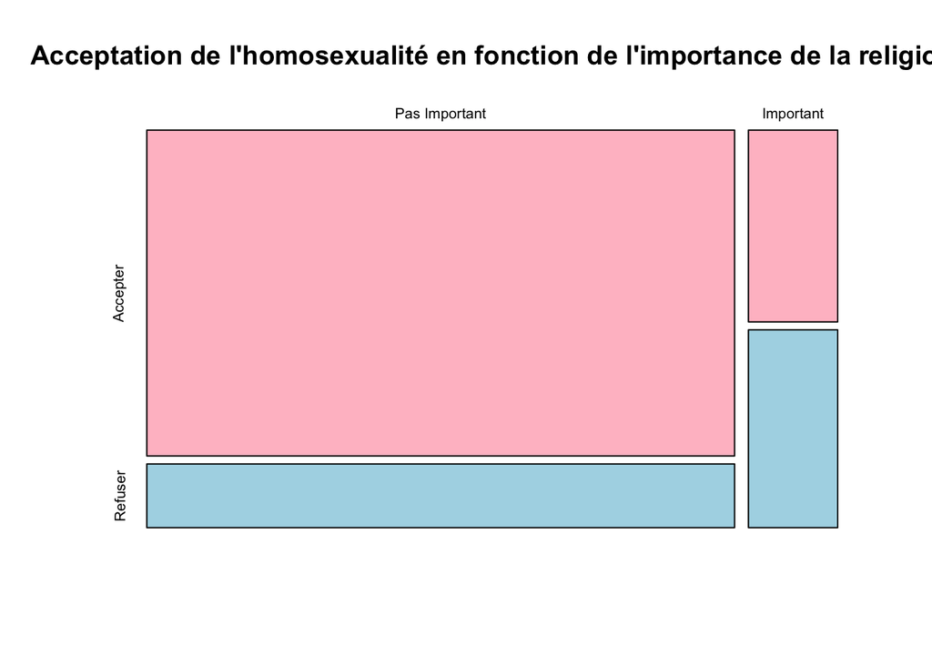

```r
mosaicplot(tab_D1,
     col=c("pink","lightblue"),
     main="Acceptation de l'homosexualité en fonction de l'importance de la religion")
```

#### Tableaux de pourcentage

```r
# en ligne
kable(lprop(tab_D1), digits=1, caption = "% en ligne")
```

% en ligne

|  | Accepter | Refuser | Total |
| --- | --- | --- | --- |
| Pas Important | 83.6 | 16.4 | 100 |
| Important | 49.2 | 50.8 | 100 |
| All | 79.1 | 20.9 | 100 |

```r
# en colonne
kable(cprop(tab_D1), digits=1, caption = "% en colonne")
```

% en colonne

|  | Accepter | Refuser | All |
| --- | --- | --- | --- |
| Pas Important | 91.8 | 68 | 86.8 |
| Important | 8.2 | 32 | 13.2 |
| Total | 100.0 | 100 | 100.0 |

```r
# total
kable(prop(tab_D1), digits=1, caption = "% du total")
```

% du total

|  | Accepter | Refuser | Total |
| --- | --- | --- | --- |
| Pas Important | 72.6 | 14.2 | 86.8 |
| Important | 6.5 | 6.7 | 13.2 |
| Total | 79.1 | 20.9 | 100.0 |

**Tableau de pourcentage en ligne** : indique la répartition des modalités de l’opinion sur l’homosexualité (“Accepter” ou “Refuser”) au sein de chaque modalité de religion (“Important”, “Pas important”). Ici, parmi les personnes pour qui la religion est importante en 2002, 49,2% acceptent l’homosexualité et 50,8% la refusent.

**Tableau de pourcentage en colonne** : indique la répartition des catégories de religion au sein de chaque opinion sur l’homosexualité. Ici, parmi ceux qui ont répondu “Accepter l’homosexualité”, 91,8% considèrent la religion comme pas importante et 8,2% comme importante.

**Tableau de pourcentage du total** : Sur l’ensemble des répondants, 72,6% sont des individus pour qui la religion n’est pas importante et qui acceptent l’homosexualité, tandis que 14,2% la refusent.

On peut déjà, d’après ces premiers résultats, s’avancer sur une possible relation entre le rapport à la religion et l’acceptation de l’homosexualité. Vérifions avec le test du Chi-2.

#### test du chi-2

```r
# Test
mod<-chisq.test(tab_D1)
mod
```

```
##
##  Pearson's Chi-squared test with Yates' continuity correction
##
## data:  tab_D1
## X-squared = 38.381, df = 1, p-value = 5.819e-10
```

Nous avons testé la relation entre l’importance de la religion et l’opinion sur l’homosexualité en 2002 à l’aide du test du Chi-2.

La valeur du Chi-2 est de 38,381, avec un dégré de liberté de 1, et une p-value extrêmement faible (<0,01). Comme la p-value est bien inférieure à 0,01, nous rejetons l’hypothèse nulle (H0) qui indique qu’il n’y a pas de relation entre les deux variables. Ces résultats montrent qu’il existe une **relation statistiquement significative** entre l’importance accordée à la religion et l’opinion sur l’homosexualité en 2002.

En d’autres termes, l’importance accordée à la religion semble influencer de manière significative la position des individus sur l’acceptation ou le refus de l’homosexualité.

## B.2 : Relation entre religion et opinion sur l’homosexualité en 2019

#### tableau de contingence

```r
don2$X<-don2$rel_opi
tab_D2<-wtd.table(don2$X,don2$Y,weights = don2$poids)
kable(addmargins(tab_D2), digits=0)
```

|  | Accepter | Refuser | Sum |
| --- | --- | --- | --- |
| Pas Important | 629 | 35 | 664 |
| Important | 256 | 58 | 314 |
| Sum | 885 | 93 | 978 |

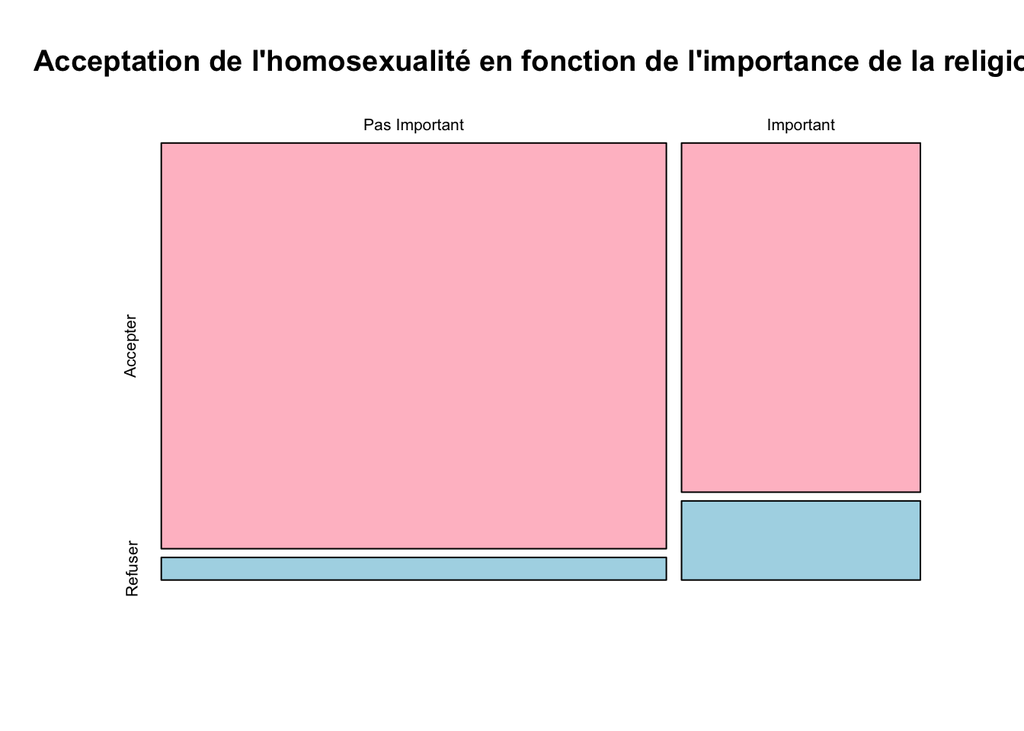

```r
mosaicplot(tab_D2,
     col=c("pink","lightblue"),
     main="Acceptation de l'homosexualité en fonction de l'importance de la religion")
```

#### Tableaux de pourcentage

```r
# en ligne
kable(lprop(tab_D2), digits=1, caption = "% en ligne")
```

% en ligne

|  | Accepter | Refuser | Total |
| --- | --- | --- | --- |
| Pas Important | 94.7 | 5.3 | 100 |
| Important | 81.5 | 18.5 | 100 |
| All | 90.5 | 9.5 | 100 |

```r
# en colonne
kable(cprop(tab_D2), digits=1, caption = "% en colonne")
```

% en colonne

|  | Accepter | Refuser | All |
| --- | --- | --- | --- |
| Pas Important | 71.1 | 37.6 | 67.9 |
| Important | 28.9 | 62.4 | 32.1 |
| Total | 100.0 | 100.0 | 100.0 |

```r
# total
kable(prop(tab_D2), digits=1, caption = "% du total")
```

% du total

|  | Accepter | Refuser | Total |
| --- | --- | --- | --- |
| Pas Important | 64.3 | 3.6 | 67.9 |
| Important | 26.2 | 5.9 | 32.1 |
| Total | 90.5 | 9.5 | 100.0 |

**Tableau de pourcentage en ligne** : Ici, parmi les personnes pour qui la religion n’est pas importante en 2019, 94,7% acceptent l’homosexualité et 5,3% la refusent.

**Tableau de pourcentage en colonne** : indique la répartition des catégories de religion au sein de chaque opinion sur l’homosexualité. Ici, parmi ceux qui ont répondu “Accepter l’homosexualité” en 2019, 71,1% considèrent la religion comme pas importante et 28,9% comme importante.

**Tableau de pourcentage du total** : Sur l’ensemble des répondants, 64,3% sont des individus pour qui la religion n’est pas importante et qui acceptent l’homosexualité, tandis que 3,6% la refusent.

On peut déjà, d’après ces premiers résultats, s’avancer sur une possible relation entre le rapport à la religion et l’acceptation de l’homosexualité en 2019. Mais moins forte qu’en 2002… Vérifions avec le test du Chi-2 et comparons ensuite.

#### test du chi-2

```r
# Test
mod<-chisq.test(tab_D2)
mod
```

```
##
##  Pearson's Chi-squared test with Yates' continuity correction
##
## data:  tab_D2
## X-squared = 41.649, df = 1, p-value = 1.092e-10
```

Nous avons testé la relation entre l’importance de la religion et l’opinion sur l’homosexualité en 2019 à l’aide du test du Chi-2.

La valeur du Chi-2 est de 41,649, avec un dégré de liberté de 1, et une p-value extrêmement faible (<0,01). Comme la p-value est bien inférieure à 0,01, nous rejetons l’hypothèse nulle (H0) qui indique qu’il n’y a pas de relation entre les deux variables. Ces résultats montrent qu’il existe une **relation statistiquement significative** entre l’importance accordée à la religion et l’opinion sur l’homosexualité en 2019.

En d’autres termes, l’importance accordée à la religion semble influencer de manière significative la position des individus sur l’acceptation ou le refus de l’homosexualité en 2019.

On remarque des légers changement entre 2002 et 2019.

## B.3 Conclusion : comparaison de votre pays avec un ou deux autres pays

Quand on compare avec l’Allemagne, on remarque que dans ce pays, les personnes qui pensent que la religion n’est pas importante ont plus tendance à accepter l’homosexualité que ce soit en 2002 ou en 2019. Les p-values sont très faibles en allemagne également, tout comme en France. En Allemagne et en France, il y a approximativement le même degré de significativité pour la relation entre l’importance de la religion et l’opinion sur l’homosexualité.

# C. INFLUENCE DU SEXE SUR l’OPINION (4 pts)

Les hommes et les femmes ont-ils des opinions différentes sur l’homosexualité ?

## C.1 : Relation entre sexe et opinion sur l’homosexualité en 2002

#### tableau de contingence

```r
don1$X<-don1$sex
tab<-wtd.table(don1$X,don1$hom_opi)
kable(addmargins(tab), digits=0)
```

|  | Accepter | Refuser | Sum |
| --- | --- | --- | --- |
| Homme | 173 | 60 | 233 |
| Femme | 219 | 44 | 263 |
| Sum | 392 | 104 | 496 |

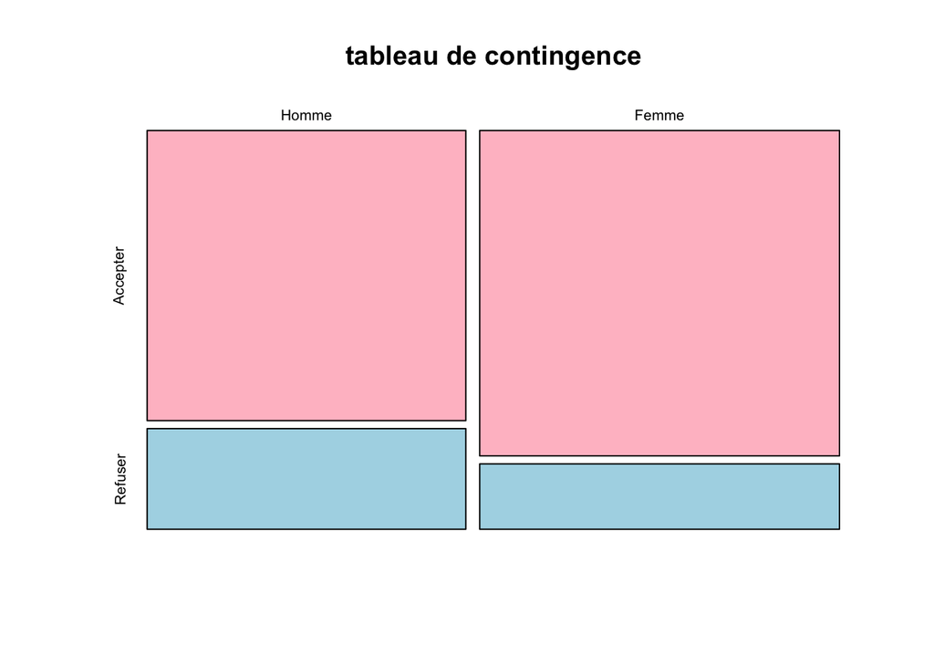

```r
mosaicplot(tab,
   col=c("pink","lightblue"),
     main="tableau de contingence")
```

#### Tableau de pourcentage

```r
kable(lprop(tab), digits=1, caption = "% en ligne")
```

% en ligne

|  | Accepter | Refuser | Total |
| --- | --- | --- | --- |
| Homme | 74.2 | 25.8 | 100 |
| Femme | 83.3 | 16.7 | 100 |
| All | 79.0 | 21.0 | 100 |

Ici, parmi les Hommes en 2002, 74,2% acceptent l’homosexualité et 25,8% la refusent. Chez les femmes, 83% l’acceptent et 16% la refusent.

#### Chi-2

```r
# Test
mod<-chisq.test(tab)
mod
```

```
##
##  Pearson's Chi-squared test with Yates' continuity correction
##
## data:  tab
## X-squared = 5.535, df = 1, p-value = 0.01864
```

La p-value est inférieure à 0,05, ce qui nous permet de rejeter l’hypothèse nulle (H0). Il existe donc une relation légèrement significative entre le sexe et l’opinion sur l’homosexualité en 2002. Autrement dit, le sexe semble légèrement avoir une influence sur l’opinion concernant l’homosexualité en 2002.

## C.2 : Relation entre sexe et opinion sur l’homosexualité en 2019

#### tableau de contingence

```r
don2$X<-don2$sex
tab2<-wtd.table(don2$X,don2$hom_opi)
kable(addmargins(tab2), digits=0)
```

|  | Accepter | Refuser | Sum |
| --- | --- | --- | --- |
| Homme | 518 | 64 | 582 |
| Femme | 373 | 29 | 402 |
| Sum | 891 | 93 | 984 |

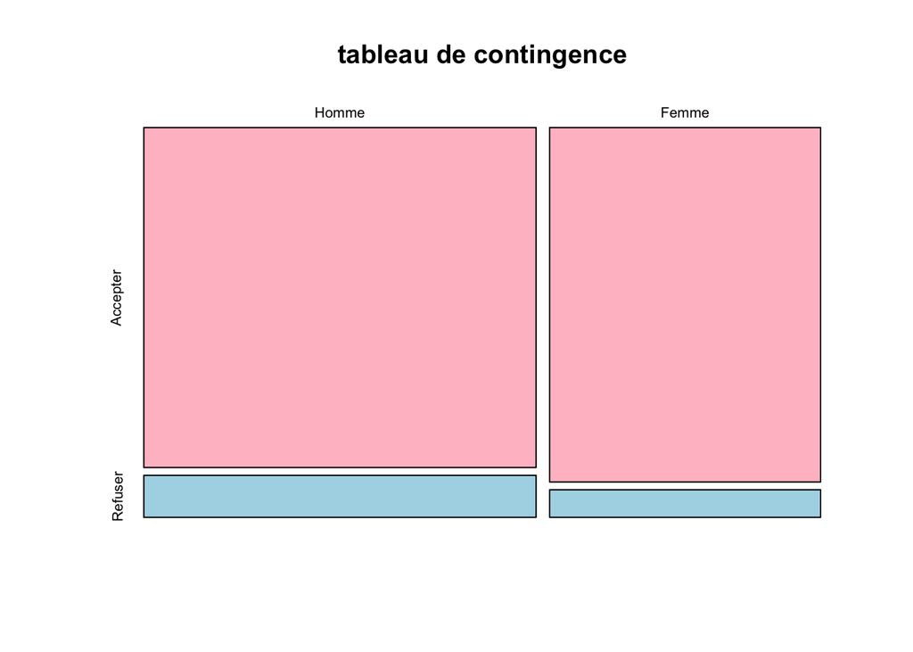

```r
mosaicplot(tab2,
     col=c("pink","lightblue"),
     main="tableau de contingence")
```

#### Tableau de pourcentage

```r
kable(lprop(tab2), digits=1, caption = "% en ligne")
```

% en ligne

|  | Accepter | Refuser | Total |
| --- | --- | --- | --- |
| Homme | 89.0 | 11.0 | 100 |
| Femme | 92.8 | 7.2 | 100 |
| All | 90.5 | 9.5 | 100 |

Ici, parmi les Hommes en 2019, 89% acceptent l’homosexualité et 11% la refusent. Chez les femmes, 92% acceptent et 7% la refusent.

#### Chi-2

```r
# Test
mod<-chisq.test(tab2)
mod
```

```
##
##  Pearson's Chi-squared test with Yates' continuity correction
##
## data:  tab2
## X-squared = 3.5456, df = 1, p-value = 0.0597
```

La p-value est légèrement supérieure à 0,05. Cela signifie que l’hypothèse nulle (H0) ne peut pas être rejetée au seuil de 5%. En conséquence, **aucune relation statistiquement significative** n’est mise en évidence entre le sexe et l’acceptation en l’homosexualité en 2019.

Entre 2002 et 2019, la relation entre le sexe et l’opinion sur l’homosexualité a **évolué**.

En 2002, le sexe jouait un rôle légèrement significatif dans les opinions, avec des différences entre hommes et femmes. En 2019, ces différences se sont atténuées, la p-value a augmentée, suggérant une **homogénéisation des opinions** entre les sexes sur cette question. Cette évolution pourrait refléter un changement sociétal et une diminution des écarts d’opinions entre certains groupes démographiques, comme les sexes.

## C.3 Conclusion : comparer avec un autre pays.

En Allemagne en 2002, le sexe avait tendance à influencer l’opinion sur l’homosexualité de manière significative. En 2019 également. Les femmes acceptaient plus l’homosexualité pendant ces deux années. Il y a une légère différence avec la France, ou la relation n’est plus très significative en 2019…

En Pologne, de manière globale, les femmes ont toujours été plus favorables à l’acceptation de l’homosexualité, mais l’écart à diminué en 2019 par rapport à 2002.

# D. INFLUENCE DE L’AGE OU DE LA GENERATION (4 pts)

Vous allez choisir (au choix) l’âge ou la génération et effectuer un découpage en 3 ou 4 classes. Puis vous allez examiner si cette variable a une influence sur l’opinion dans votre pays.

## D.1 : Relation entre age et opinion sur l’homosexualité en 2002

#### tableau de contingence

```r
don1$X<-don1$age3
tab3<-wtd.table(don1$X,don1$Y)
kable(addmargins(tab3), digits=0)
```

|  | Accepter | Refuser | Sum |
| --- | --- | --- | --- |
| Jeunes | 84 | 15 | 99 |
| Adultes | 208 | 30 | 238 |
| Agé | 100 | 59 | 159 |
| Sum | 392 | 104 | 496 |

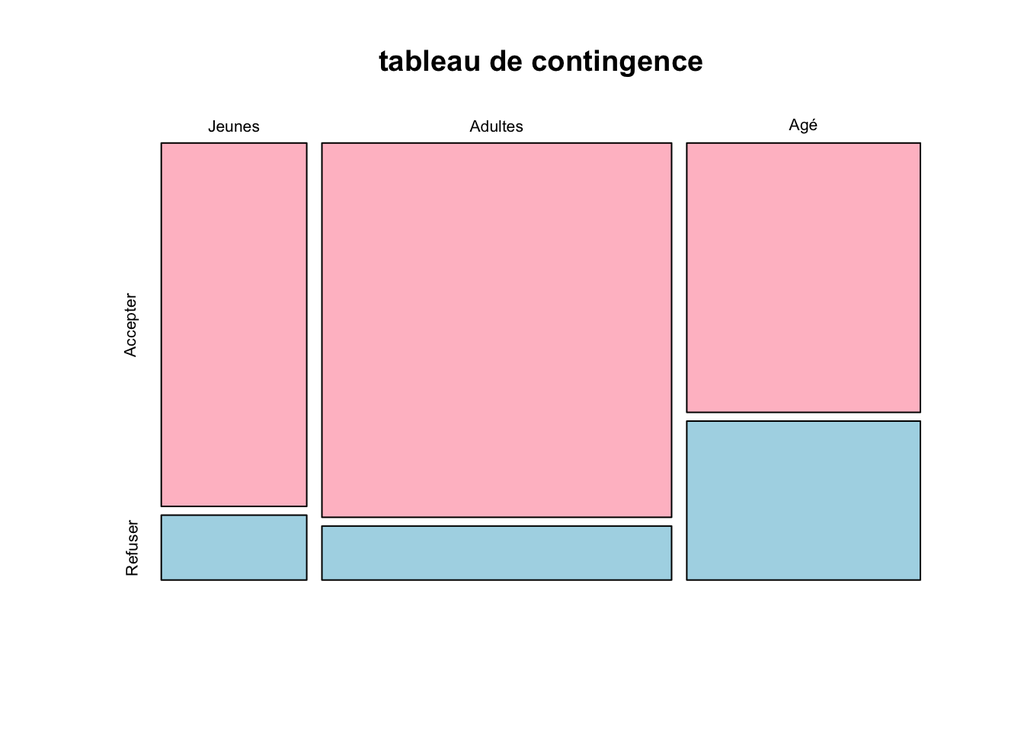

```r
mosaicplot(tab3,
     col=c("pink","lightblue"),
     main="tableau de contingence")
```

#### Tableau de pourcentage

```r
kable(lprop(tab3), digits=1, caption = "% en ligne")
```

% en ligne

|  | Accepter | Refuser | Total |
| --- | --- | --- | --- |
| Jeunes | 84.8 | 15.2 | 100 |
| Adultes | 87.4 | 12.6 | 100 |
| Agé | 62.9 | 37.1 | 100 |
| All | 79.0 | 21.0 | 100 |

#### Chi-2

```r
# Test
mod<-chisq.test(tab3)
mod
```

```
##
##  Pearson's Chi-squared test
##
## data:  tab3
## X-squared = 37.057, df = 2, p-value = 8.977e-09
```

La p-value est extrêmement faible (< 0,05), ce qui permet de rejeter l’hypothèse nulle (H0). Il existe donc une relation statistiquement significative entre l’âge et l’opinion sur l’homosexualité en 2002. A l’aide du graphique, on remarque que les personnes agées (entre 56 et 100 ans) on tendance à moins accepter l’homosexualité.

## D.2 : Relation entre age et opinion sur l’homosexualité en 2019

#### tableau de contingence

```r
don2$X<-don2$age3
tab4<-wtd.table(don2$X,don2$Y)
kable(addmargins(tab4), digits=0)
```

|  | Accepter | Refuser | Sum |
| --- | --- | --- | --- |
| Jeunes | 156 | 15 | 171 |
| Adultes | 379 | 36 | 415 |
| Agé | 356 | 42 | 398 |
| Sum | 891 | 93 | 984 |

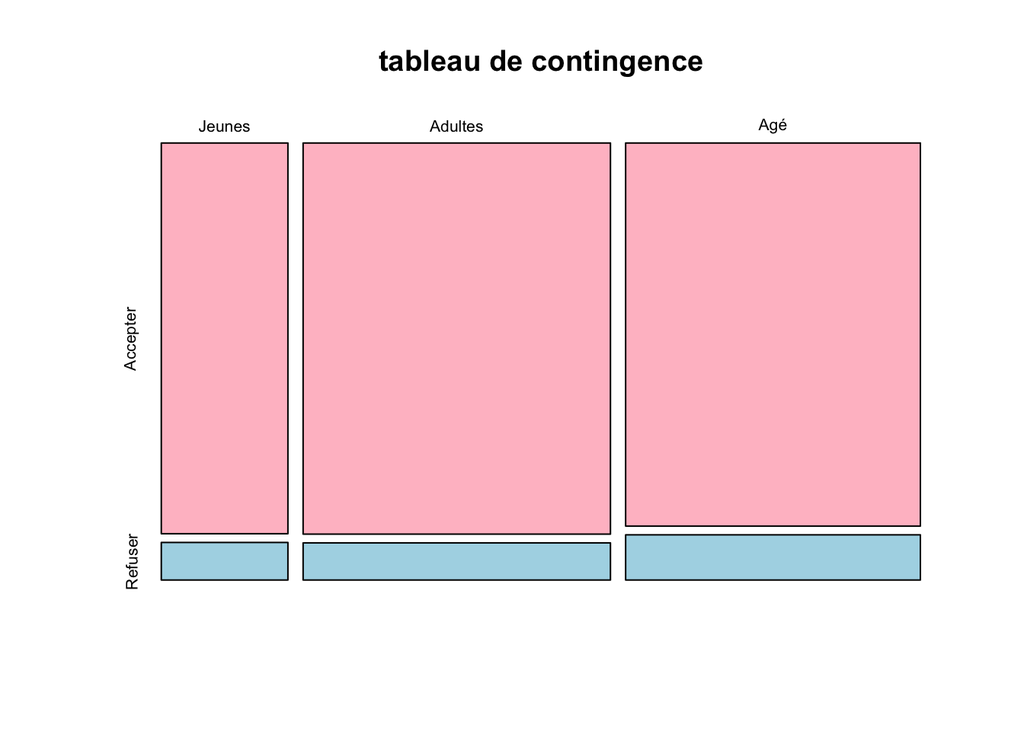

```r
mosaicplot(tab4,
     col=c("pink","lightblue"),
     main="tableau de contingence")
```

#### Tableau de pourcentage

```r
kable(lprop(tab4), digits=1, caption = "% en ligne")
```

% en ligne

|  | Accepter | Refuser | Total |
| --- | --- | --- | --- |
| Jeunes | 91.2 | 8.8 | 100 |
| Adultes | 91.3 | 8.7 | 100 |
| Agé | 89.4 | 10.6 | 100 |
| All | 90.5 | 9.5 | 100 |

On remarque grace au tableau de proportionnalité que l’écart entre tranche d’ages se réduit.

#### Chi-2

```r
# Test
mod<-chisq.test(tab4)
mod
```

```
##
##  Pearson's Chi-squared test
##
## data:  tab4
## X-squared = 0.94891, df = 2, p-value = 0.6222
```

## D.3 Conclusion : comparaison de votre pays avec un ou deux autres pays

On compare avec l’Allemagne, avec globalement les mêmes tranches d’âge. Chez eux, en 2002, les personnes agées (59-100 ans) étaient plutôt contre. Il y avait une relation significative entre la tranche d’âge et l’opinion sur l’homosexualité. En 2019, il n’y a plus de significativité avec une p-value à 0,9. Ces résultats s’apparentent grandement à la France.

En Pologne, l’acceptation de l’homosexualité a progressé entre 2002 et 2019 mais des ecarts important restent toujours avec l’âge. Les jeunes ont tendance à plus accepter l’homosexualité. En France, l’acceptation est globalement plus élevée qu’en Pologne, avec une influence moins marquées de l’age sur l’opinion. Les opinions en France sont plus uniformes.

# E. CONCLUSION (2 pts)

Quand on compare la France aux deux autres pays, elle se place globalement dans une acceptation de l’homosexualité, que ce soit en 2002 ou en 2019.